# Assignment 1 (solutions)

EFB 796: Techniques and Concepts in Movemenent Ecology

Elie Gurarie

Winter/Spring 2023

### I. Basic manipulations of movement data

1. Provide a brief summary of the data - what is it, where did it come from,

> In part to illustrate some places where movement data are “tucked away” in R, here’s an example of a [mouflon (*Ovis gmelini*)](https://en.wikipedia.org/wiki/Mouflon) in the `adehabitatLT` package. This particular mouflon was tracked in 2003 somewhere in southern France, data from the Office National de la Chasse et de la Faune Sauvage - the national game and wildlife agency of France.
2. Load the data, convert the coordinates to complex numbers, plot the data (with a fixed aspect ratio)

> The following bit of code extracts one of two mouflons in the package, retaining only the *x*, *y* and *date* (time) columns, which as all we need. Note that the time vector is already in POSIX format.

```r
require(adehabitatLT)
# See all the data in the package by running:
## >  data(package = "adehabitatLT")
data(mouflon)  # loads the data.
mouflon <- as.data.frame(mouflon[[1]][,1:3])
str(mouflon)
```

```
## 'data.frame':    135 obs. of  3 variables:
##  $ x   : num  650634 650569 650589 650554 650468 ...
##  $ y   : num  1844951 1844938 1844963 1844959 1845157 ...
##  $ date: POSIXct, format: "2003-11-02 06:40:00" "2003-11-02 07:00:00" ...
```

> There is a bit of an issue with some missing observations in these data

```r
table(is.na(mouflon$x))
```

```
##
## FALSE  TRUE
##   125    10
```

> A simple way to tidy those (for our purposes) is simply:

```r
mouflon <- na.omit(mouflon)
```

> Creating a complex vector and plotting the movement:

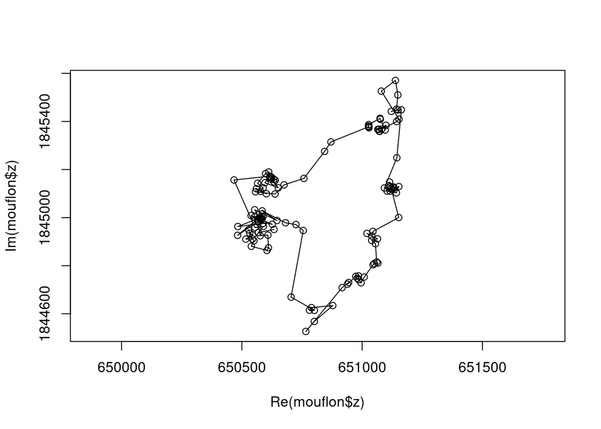

```r
mouflon$z <- mouflon$x + 1i * mouflon$y
plot(mouflon$z, asp = 1, type = "o")
```

3. Report some basic stats: how many observations are there; what is the sampling rate (aka *duty cycle*); what is the total extent in the east-west direction and north-south direction?

> Check out this R markdown trick for reporting stats. If I type:

```
There are `r nrow(mouflon)` locations in the data base, spanning `r round(diff(range(mouflon$x)))` m East-West, and `r round(diff(range(mouflon$y)))` m North-South.
```

> The output is: *There are 125 locations in the data base, spanning 695 m East-West, and 1044 m North-South.*, and so on. The other important piece of infromation I asked for was the sampling rate, which is obtained by:

```r
dT <- difftime(mouflon$date[-1], mouflon$date[-nrow(mouflon)], "minutes")
table(round(dT,-1))
```

```
##
##  20  40 140
## 119   4   1
```

> almost all of the time intervals are 20 minutes, with a few 40 minute intervals (because of single missing locations), and one of 140 minutes (because of 6 missing locations).
4. Compute the **step lengths** ($S$), report the mean, standard deviation, and draw a histogram,

```r
dS <- Mod(diff(mouflon$z))
mean(dS)
```

```
## [1] 49.45847
```

```r
sd(dS)
```

```
## [1] 50.471
```

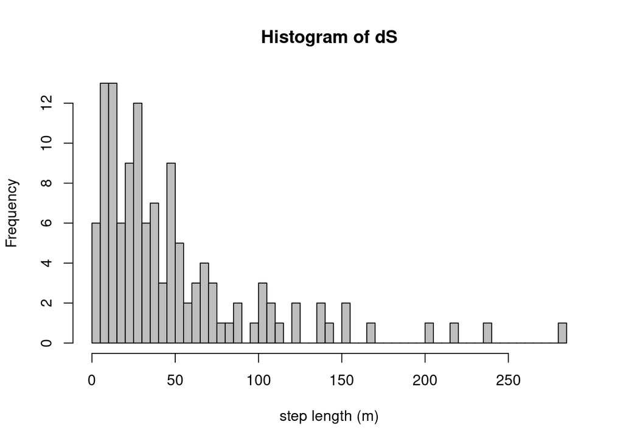

```r
hist(dS, breaks = 50, col = "grey",xlab = "step length (m)")
```

> So, in 20 minutes the mouflon typically moves 50 m (sd 50 m). **POP QUIZ: What is a distribution where the mean and standard deviation are equal?** Note also that since not ALL step durations are 20 minutes, this is a slightly biased analysis.

```r
mouflon[which.max(dS) + c(-1:1),]
```

```
##            x       y                date               z
## 99  650801.5 1844614 2003-11-03 15:20:00 650802+1844614i
## 100 650704.7 1844669 2003-11-03 15:40:00 650705+1844669i
## 101 650755.1 1844946 2003-11-03 16:00:00 650755+1844946i
```

5. Compute the **absolute orientations** of the steps ($\Phi$), report the *mean* ($\widehat{\mu} = \overline{\Phi}$), the *mean cosine* ($\widehat{\rho} = \overline{\cos(\Phi)}$), and draw a histogram and rose diagram of the angles.

> The key is to take the argument of the *steps*, i.e. of `diff(z)`:

```r
Phi <- Arg(diff(mouflon$z))
```

> The rest follows directly

```r
mean(Phi)
```

```
## [1] -0.1762241
```

```r
mean(cos(Phi))
```

```
## [1] 0.001033232
```

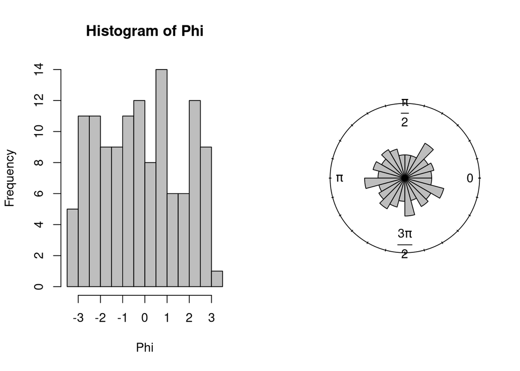

```r
hist(Phi, breaks = 20, col = "grey")
require(circular)
rose.diag(Phi, bins = 24, prop = 2, col = "grey")
```

> The angles are more less uniformy distributed between $-\pi$ and $\pi$ - as expected. The mean AND mean cosine are near 0, indiciating no overall orientation to the movement.
6. Perform the steps above for **turning angles** ($\Theta$).

> The turning angles are the *differences* in the absolute orientations:

```r
Theta <- diff(Phi)
```

> The rest follows directly as abbove:

```r
mean(Theta)
```

```
## [1] 0.03993427
```

```r
mean(cos(Theta))
```

```
## [1] -0.1625449
```

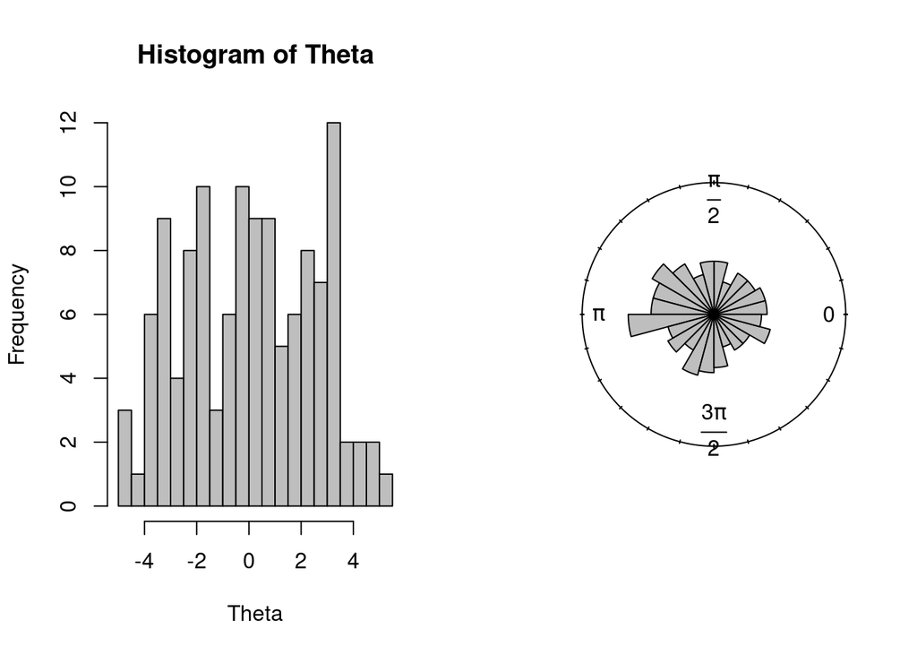

```r
hist(Theta, breaks = 20, col = "grey")
rose.diag(Theta, bins = 24, prop = 2, col = "grey")
```

```r
steps <- diff(mouflon$z)
long_steps <- steps[Mod(steps) > 50]
mean(cos(diff(Arg(long_steps))))
```

```
## [1] 0.1606068
```

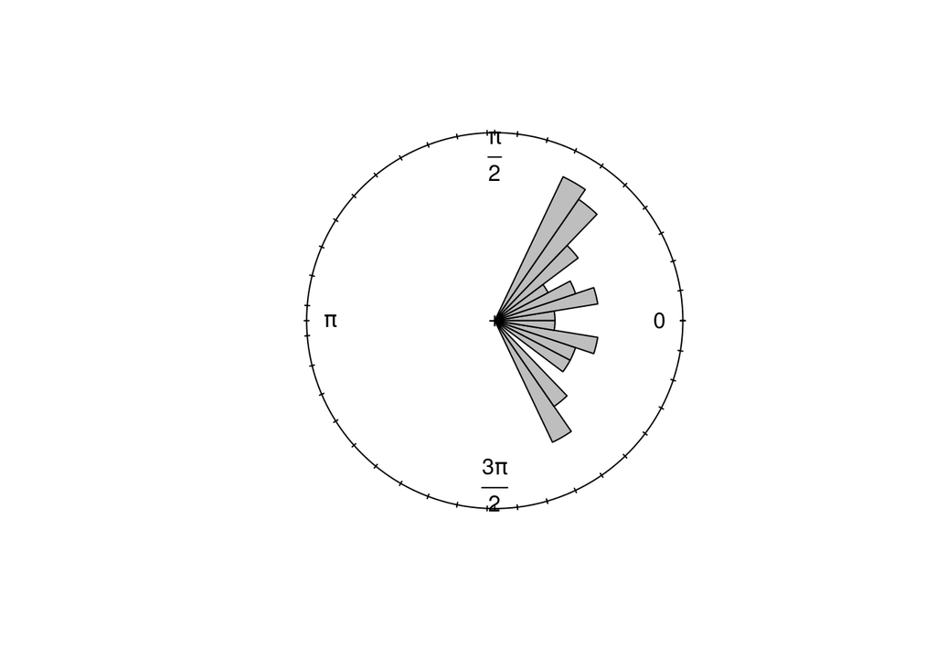

```r
rose.diag(cos(diff(Arg(long_steps))), prop = 2, col = "grey")
```

> Ah! Much better. The $\widehat{\rho} > 0$, and most of the angles are “forward” looking.
7. What do you think the statistic $\widehat{\rho}$ tells you?

> If $\rho = 1$, all the movement is in the same direction. If $\rho = 0$ the turning angles are completely random. If $\rho < 0$ the movements tend to go back and forth.

[figure not shown]

Mouflon - by Karl Joseph Brodtmann

### II. Simple statistics on spatial data (with some self-learning).

I emailed you a file, `AmericanBeech.csv` which contains the coordinates of American beech trees (*Fagus grandifola*) measured at SUNY-ESF’s Adirondack Research Station in 1985, 2000 and 2009 (data courtesy of [M. Dovciak](https://www.esf.edu/faculty/dovciak/)).

1. Load those data, convert the coordinates to complex numbers, and plot.

```r
## beech <- read.csv("AmericanBeech.csv")
str(beech)
```

```
## 'data.frame':    219 obs. of  5 variables:
##  $ EAST : num  17 46.9 42 19.5 32.6 ...
##  $ NORTH: num  10.5 49.9 16.3 34.9 15.7 ...
##  $ DBH85: num  54.9 42.7 46.4 45.2 44 47.8 41.4 46.4 44.8 42.1 ...
##  $ DBH00: num  57 49.5 50.9 48.5 47.8 49 45.5 46.8 46.9 42.8 ...
##  $ DBH09: num  58.5 53.3 52.8 51.2 50.8 50.3 49.1 48.1 47.2 47 ...
```

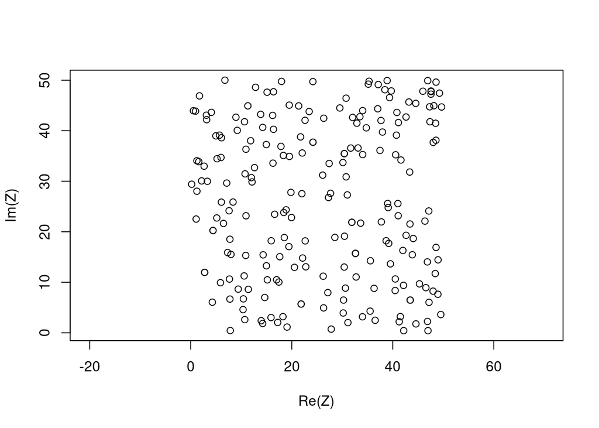

```r
Z <- beech$EAST + 1i*beech$NORTH
plot(Z, asp = 1)
```

2. Use `outer` and `apply` to compute the distance from each tree to it’s nearest neighbor,

> To use `outer()`, you need a function that takes two arguments and returns a single value. But those arguments can be *complex*! So the distance between two points functions can be:

```r
getDistance <- function(z1, z2) Mod(z2 - z1)
```

> Applying this across all combinations of points giv es:

```r
D.matrix <- outer(Z, Z, getDistance)
```

Let’s take a quick peek at this matix:

```r
D.matrix[1:5,1:5]
```

```
##          [,1]     [,2]      [,3]     [,4]      [,5]
## [1,]  0.00000 49.47798 25.663079 24.53798 16.461290
## [2,] 49.47798  0.00000 33.964640 31.22298 37.052843
## [3,] 25.66308 33.96464  0.000000 29.16821  9.407665
## [4,] 24.53798 31.22298 29.168213  0.00000 23.209425
## [5,] 16.46129 37.05284  9.407665 23.20942  0.000000
```

> This matrix is symmetric, because the distance between tree 1 and tree 2 is equal to the distance between tree 2 and tree 1. And it has 0’s along the diagonal, because the distance between a tree and itself is 0. Actually, *any* symmetric matrix with 0’s along the diagonals can be considered a [distance matrix](https://en.wikipedia.org/wiki/Distance_matrix) (or - formally - a distance matrix in a [*metric space*](https://en.wikipedia.org/wiki/Metric_space)). The diagonal is not very interesting, so we could replace all of those 0’s with NA’s:

```r
diag(D.matrix) <- NA
```

> Now that we have a distance matrix, we can use `apply` along the rows (or columns) get the distance of the nearest tree:

```r
NN.distances <- apply(D.matrix, 1, min, na.rm = TRUE)
```

> If you want to do everthing in one line, it would look like this:

```r
NN.distances <- apply(outer(Z, Z, function(z1, z2) Mod(z1-z2)),
                      1, function(x) min(x[x>0]))
```

> High-level stuff! Two bespoke functions defined within a single line of code!
3. Report the mean nearest neighbor distance, the inter-quartile intervals, and plot a histogram. Describe.

```r
summary(NN.distances)
```

```
##    Min. 1st Qu.  Median    Mean 3rd Qu.    Max.
## 0.02279 1.32507 1.91916 1.94243 2.40744 5.91733
```

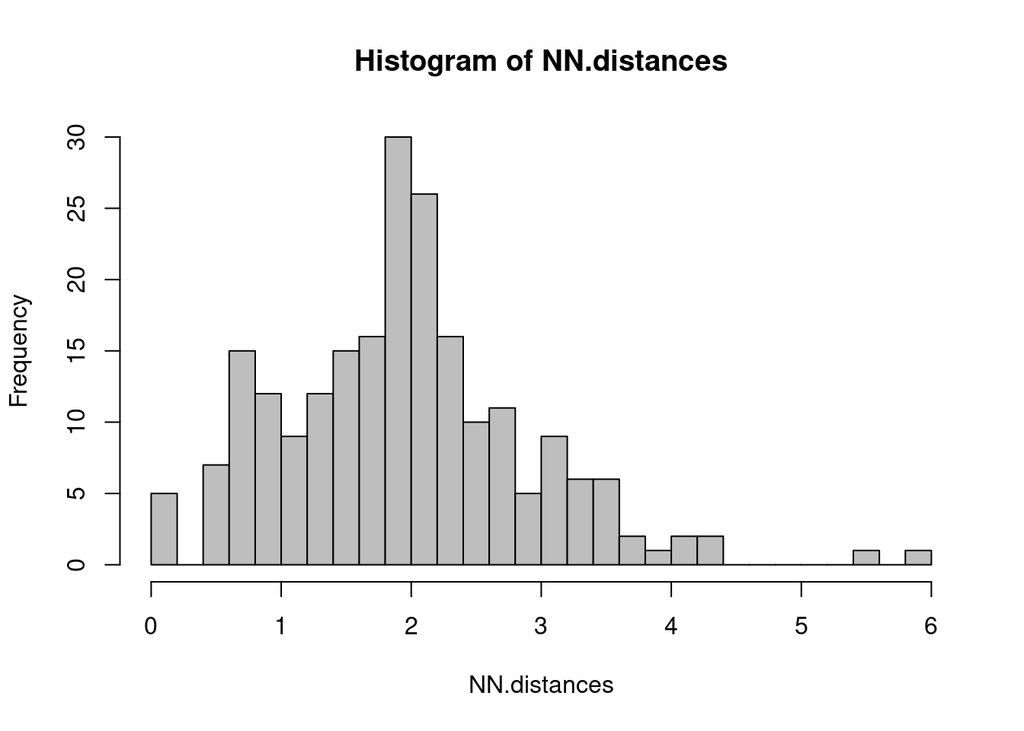

```r
hist(NN.distances, breaks = 40, col = "grey")
```

> The mean & median nearest neighber distance between trees is about 2 meters, but it looks like there might be some *inhibition* in the growth of the beech trees, i.e. below the 2 meter peak, it is much less likely to find another tree within, say 1 meter. There are real, biological reasons for this, of course, that even non-plant ecologists might surmise!